# Multivariate Analysis of US Interest Rate Dynamics Using Macroeconomic Indicators

Byeongsu Lee

2026-06-09

## Introduction

This project aims to investigate how interest rates in the United States are determined by macroeconomic conditions. Rather than focusing on a single policy rate, this project treats interest rates as a multivariate system, recognising that monetary policy decisions influence not only the Federal Funds Rate but also longer-term yields and the overall structure of the yield curve.

The primary research question is: How do macroeconomic indicators and economic regimes jointly influence the structure of interest rates in the US? In particular, this study examines whether key economic variables such as inflation, unemployment, industrial production, and consumer sentiment can explain variations in multiple interest rate measures.

The explanatory variables include CPI growth, PCE growth, industrial production growth, changes in consumer sentiment, and the unemployment rate. These variables were selected because they reflect key dimensions of macroeconomic activity that are closely associated with monetary policy decisions and interest rate movements. CPI and PCE growth capture inflationary pressures, which are central to Federal Reserve policy adjustments. Industrial production growth serves as an indicator of overall economic activity and business cycle conditions, while the unemployment rate reflects labour market conditions and economic slack. Changes in consumer sentiment are included to account for shifts in household expectations and economic confidence, both of which may influence consumption behaviour and financial market conditions.

To address the research question, this project will employ multivariate statistical techniques. Principal Component Analysis (PCA) will be used to summarise the joint behaviour of interest rates and to identify underlying components such as the overall level and slope of the yield curve. Canonical Correlation Analysis (CCA) will then be applied to examine the relationship between the set of macroeconomic variables and the set of interest rate variables, allowing for a comprehensive assessment of how economic conditions are associated with movements in the interest rate system. Canonical Correlation Analysis is particularly suitable as it allows simultaneous examination of relationships between two sets of variables, capturing joint dependence structures that cannot be identified through separate regressions.

This approach enables a deeper understanding of monetary policy transmission by analysing interest rates as an interconnected system rather than as isolated variables. The findings will provide insight into which macroeconomic factors are most strongly associated with changes in interest rates and how these relationships vary depending on the state of the economy. This study explicitly treats interest rates as a multivariate response system rather than analysing each rate independently.

## Exploratory Data Analysis

### Correlation Structure

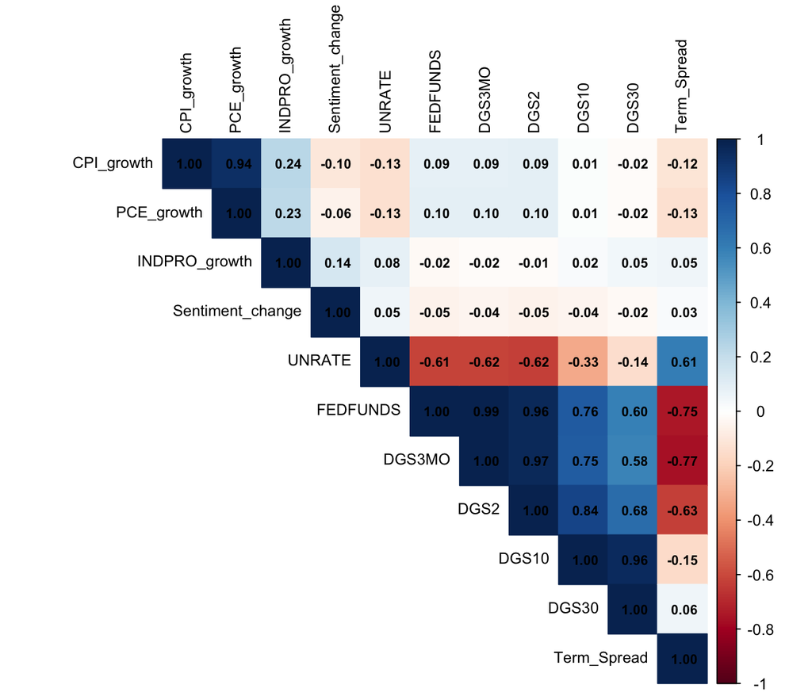

Figure 1: Correlation matrix of macroeconomic and interest-rate variables

Figure 1 shows the correlation structure among the macroeconomic and interest-rate variables.

The correlation matrix revealed strong positive correlations among Treasury yields across different maturities, indicating the presence of a common underlying interest-rate structure. In particular, the Federal Funds Rate and short-term Treasury yields exhibited near-perfect correlation, while long-term yields also remained highly correlated with medium-term rates. These relationships provide strong justification for applying Principal Component Analysis to the interest-rate variables.

The unemployment rate displayed moderate negative correlations with most interest-rate variables, suggesting that weaker labour market conditions were generally associated with lower interest-rate environments. In addition, the term spread was negatively correlated with short-term interest rates, consistent with periods of yield curve flattening or inversion during monetary tightening cycles.

### Summary Statistics

Table 1: Summary statistics for macroeconomic and interest-rate variables

| Variable | Mean | SD |
| --- | --- | --- |
| CPI_growth | 0.007 | 0.010 |
| PCE_growth | 0.006 | 0.007 |
| INDPRO_growth | 0.001 | 0.038 |
| Sentiment_change | -0.008 | 0.185 |
| UNRATE | 5.620 | 1.913 |
| FEDFUNDS | 2.031 | 2.018 |
| DGS3MO | 1.972 | 1.994 |
| DGS2 | 2.284 | 1.761 |
| DGS10 | 3.338 | 1.290 |
| DGS30 | 3.924 | 1.166 |
| Term_Spread | 1.365 | 1.339 |

Table 1 presents summary statistics for the macroeconomic and interest-rate variables used in the analysis. Treasury yields exhibited substantial variation over the sample period, reflecting changing monetary policy conditions and business cycle dynamics. The Federal Funds Rate ranged from 0.05% to 6.54%, capturing both the zero lower bound period and subsequent tightening cycles. The term spread also displayed considerable variability, including periods of yield curve inversion, with values ranging from -1.89 to 3.85 percentage points.

Among the macroeconomic variables, inflation measures (CPI and PCE growth) showed relatively low volatility compared with industrial production growth and consumer sentiment changes, both of which experienced substantial fluctuations during recessionary periods and economic recoveries.

### Yield Curve Dynamics Over Time

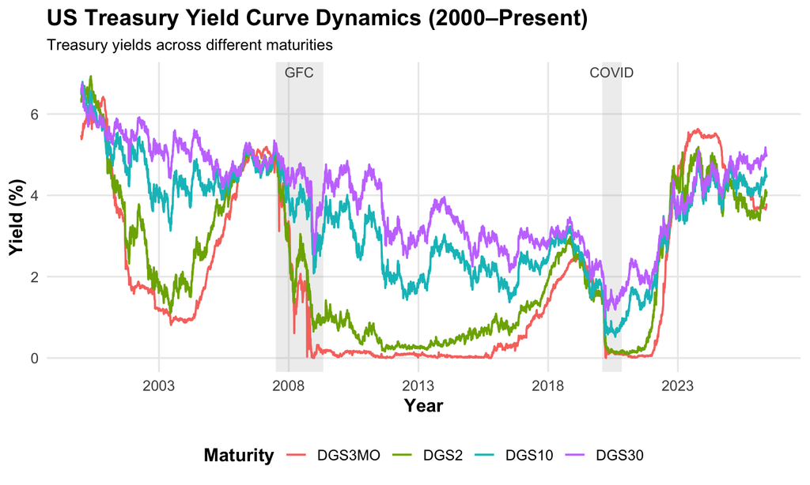

Figure 2: US Treasury yield curve dynamics across different maturities from 2000 onward

Figure 2 shows Treasury yields across different maturities over time. Treasury yields exhibited strong co-movement, although short-term yields showed substantially greater volatility than long-term yields. This pattern suggests the existence of common underlying factors affecting the yield curve, while also indicating maturity-specific responses to monetary policy and macroeconomic conditions.

Notably, short-term yields declined sharply during the Global Financial Crisis and the COVID-19 period, reflecting aggressive monetary easing by the Federal Reserve. Long-term yields remained comparatively more stable, consistent with the role of long-term interest rates in reflecting future economic expectations and inflation outlooks.

## Principal Component Analysis

### Variance Explained

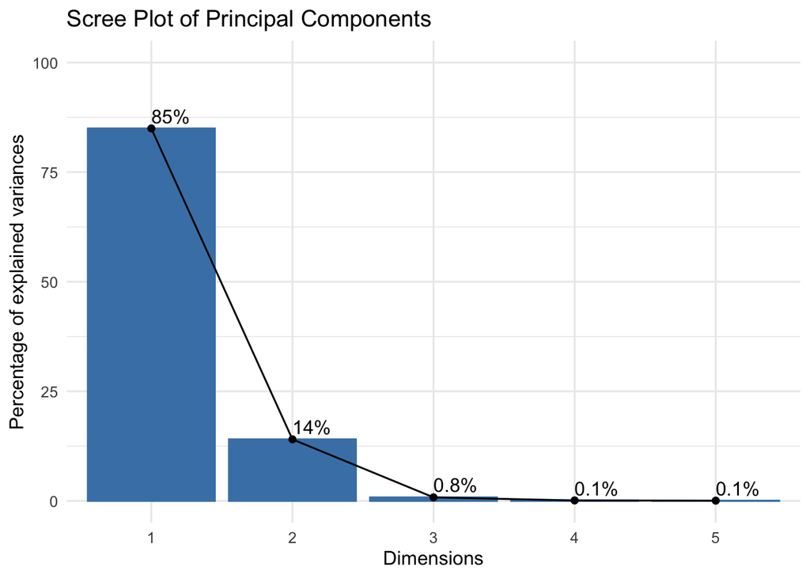

Figure 3: Scree plot showing the proportion of variance explained by each principal component

Principal Component Analysis (PCA) was applied to the interest-rate variables, including the Federal Funds Rate and Treasury yields across multiple maturities, in order to identify the main underlying factors driving the US yield curve. Although the interest-rate variables were measured on the same scale, they exhibited differing levels of volatility across maturities. The analysis was therefore conducted using standardised variables.

The PCA results and the scree plot shown in Figure 3 indicated that the first principal component (PC1) explained 85.0% of the total variance in the interest-rate data, while the second principal component (PC2) explained an additional 14.0%. Together, the first two components accounted for approximately 99.0% of the total variation, suggesting that the yield curve dynamics can largely be represented by a small number of common underlying factors.

The sign of PC1 was reversed for interpretability so that higher PC1 scores corresponded to higher overall interest-rate environments.

### Principal Component Loadings

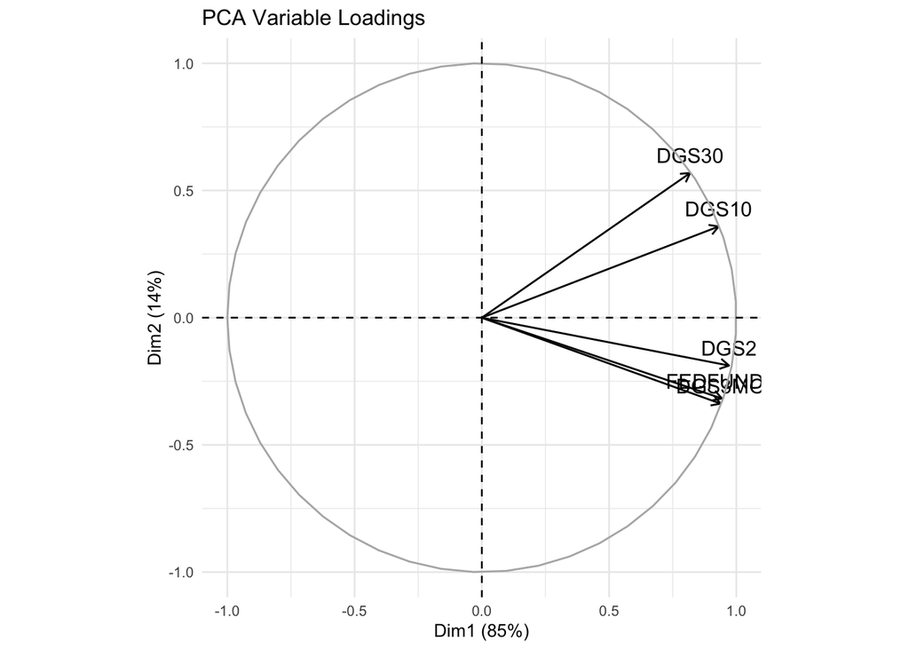

Figure 4: PCA loading plot for the first two principal components of interest-rate variables

The loading structure of the first principal component showed that all interest-rate variables loaded positively and with relatively similar magnitudes on PC1. This suggests that PC1 represents the overall level factor of the yield curve, where higher PC1 scores correspond to higher interest-rate environments across all maturities. The similarity in loadings across short-term and long-term yields indicates strong co-movement among Treasury rates over time. Full loading matrices are provided in Appendix.

The second principal component displayed a contrasting loading pattern between short-term and long-term interest rates. The Federal Funds Rate and the 3-month Treasury yield loaded negatively on PC2, while the 10-year and 30-year Treasury yields loaded positively. This pattern suggests that PC2 captures the slope factor of the yield curve, reflecting changes in the difference between short-term and long-term interest rates. In particular, increases in PC2 correspond to periods in which long-term yields rise relative to short-term yields, while decreases in PC2 are associated with yield curve flattening or inversion.

The remaining principal components explained only a very small proportion of the total variance, indicating that higher-order components contributed little additional information. Overall, the PCA results suggest that the US interest-rate structure during the sample period was primarily driven by two dominant factors: the general level of interest rates and the slope of the yield curve.

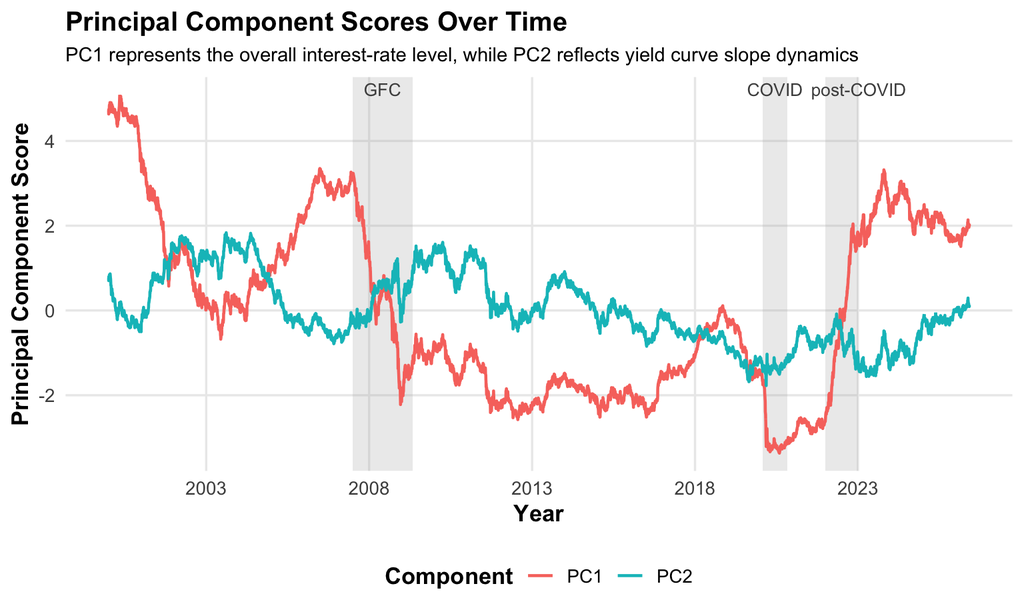

Figure 5: Time series of the first two principal component scores

Figure 5 shows the evolution of the first two principal component scores over time. PC1, interpreted as the overall interest-rate level factor, declined sharply during the Global Financial Crisis and remained persistently low throughout the post-GFC zero lower bound period. PC1 then increased substantially during the post-COVID monetary tightening cycle, reflecting the rapid rise in interest rates across maturities.

PC2, interpreted as the yield curve slope factor, exhibited greater short-term variation over time. In particular, periods associated with yield curve flattening and inversion tended to correspond to lower PC2 scores, while steeper yield curve environments were associated with higher PC2 values. The behaviour of the component scores over time further supports the interpretation of the first two principal components as representing the dominant level and slope dynamics of the US yield curve.

## Canonical Correlation Analysis

### Canonical Correlations and Redundancy Analysis

Table 2: Canonical correlations

| Canonical_Dimension | Canonical_Correlation |
| --- | --- |
| CV1 | 0.734 |
| CV2 | 0.146 |
| CV3 | 0.132 |
| CV4 | 0.068 |
| CV5 | 0.005 |

Table 3: Redundancy analysis R-squared values

[output not shown]

### Canonical Variate Relationship by Economic Period

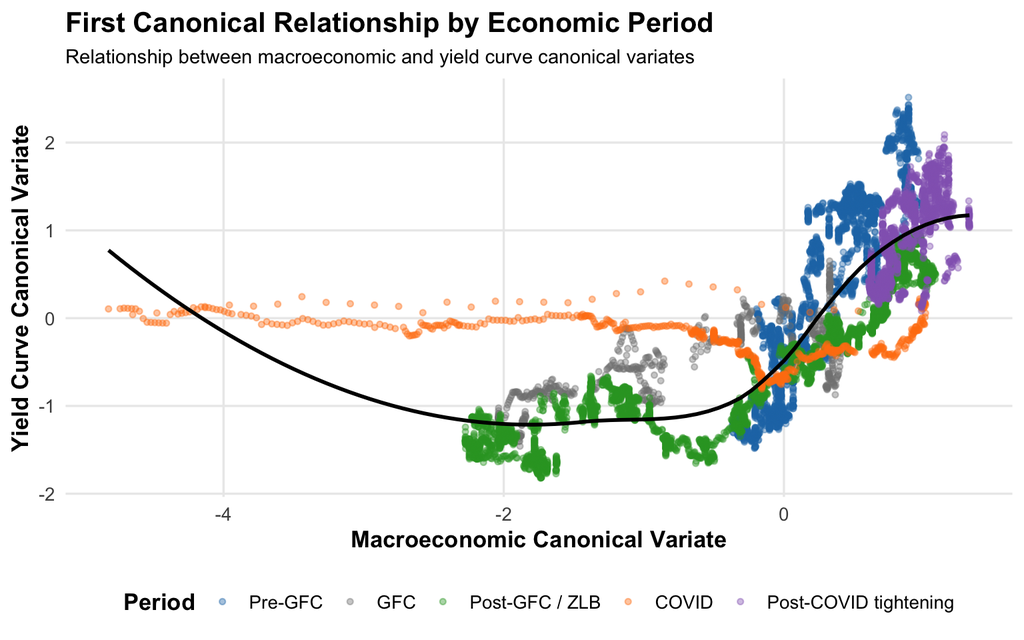

Figure 6: Relationship between the first pair of canonical variates across economic periods

Canonical Correlation Analysis (CCA) was conducted to examine the multivariate relationship between macroeconomic conditions and the structure of US interest rates. The macroeconomic variable set included inflation measures, industrial production growth, consumer sentiment changes, and the unemployment rate, while the interest-rate variable set included the Federal Funds Rate and Treasury yields across multiple maturities.

The first macroeconomic canonical variate was dominated by the unemployment rate, which exhibited a very strong negative loading (-0.997). In contrast, inflation measures and industrial production growth contributed relatively little to the first canonical dimension. On the interest-rate side, the first canonical variate was strongly associated with the Federal Funds Rate and short-term Treasury yields, particularly the 3-month and 2-year Treasury rates. Long-term Treasury yields exhibited comparatively weaker loadings, suggesting that the first canonical relationship was driven primarily by the short end of the yield curve.

Figure 6 illustrates the relationship between the first pair of canonical variates across different economic periods. A positive association was observed between the macroeconomic canonical variate and the yield curve canonical variate, although the relationship appeared non-linear.

The plot suggests that the strength and direction of the relationship differed across economic regimes. The COVID period was characterised by strongly negative macroeconomic canonical scores with relatively stable yield curve scores, reflecting the unusual monetary and economic conditions during the pandemic period. In contrast, the post-COVID tightening period showed high positive scores for both canonical variates, indicating a stronger alignment between macroeconomic conditions and yield curve movements during the recent interest-rate tightening cycle.

The GFC observations were positioned closer to the centre of the canonical space, while the Post-GFC period tended to show lower yield curve canonical scores. Overall, the clustering patterns suggest that the relationship between macroeconomic indicators and the yield curve was not stable over time, but instead varied substantially across different monetary policy and economic environments.

These findings suggest that labour market conditions were strongly associated with movements in short-term interest rates across different monetary policy regimes over the sample period. In particular, lower unemployment tended to coincide with higher short-term interest rates, consistent with periods of monetary policy tightening and stronger economic activity. Overall, the CCA results indicate that variation in the US yield curve was not only driven by common latent interest-rate factors identified in the PCA, but was also systematically related to broader macroeconomic conditions, particularly labour market performance.

## Discussion

This study applied multivariate statistical techniques to examine the relationship between US macroeconomic conditions and the structure of interest rates over time. The exploratory analysis indicated that Treasury yields across different maturities were highly correlated, suggesting that the yield curve is driven by a smaller number of underlying latent factors. The correlation heatmap further demonstrated strong positive relationships among short- and long-term interest rates, while macroeconomic indicators such as inflation and unemployment exhibited more moderate associations with yield variables.

The PCA results indicated that most of the variation in the interest-rate variables could be explained by a very small number of principal components. In particular, the first principal component explained approximately 85% of the total variance, indicating the presence of a dominant common level factor affecting yields across maturities. The second principal component captured an additional 14% of the variance and appeared to reflect differences between short- and long-term rates, consistent with the slope structure of the yield curve commonly discussed in financial economics. Together, the first two principal components explained approximately 99% of the total variation in the yield variables, suggesting that the US yield curve can be effectively summarised by a low-dimensional structure.

The canonical loadings revealed that the unemployment rate played the dominant role within the macroeconomic variable set, while short-term interest rates, including the Federal Funds Rate and short-maturity Treasury yields, contributed most strongly to the interest-rate canonical variate. This finding suggests that labour market conditions were closely associated with short-term monetary policy dynamics over the sample period. In particular, periods of lower unemployment tended to coincide with higher policy-sensitive interest rates, consistent with monetary tightening during periods of stronger economic activity.

Figure 6 supported these findings visually, showing a non-linear relationship and clear clustering by economic period between the first pair of canonical variates. The clustering by economic period suggests that the macroeconomic-yield relationship differed substantially across monetary policy and economic regimes, rather than remaining stable over the full sample period.

Despite these limitations, the findings demonstrate that multivariate statistical methods provide a useful framework for analysing the joint behaviour of macroeconomic conditions and the yield curve. The combination of PCA and CCA allowed the analysis to both reduce the dimensionality of the yield data and investigate how those latent interest-rate structures relate to broader economic conditions.

## Conclusion

This project examined the relationship between US macroeconomic indicators and interest-rate dynamics using Principal Component Analysis (PCA) and Canonical Correlation Analysis (CCA). The results showed that the yield curve is largely driven by a small number of latent factors, with the first principal component representing a dominant common movement across Treasury yields and the second component reflecting differences between short- and long-term maturities.

The CCA results further demonstrated that macroeconomic conditions were significantly associated with the structure of interest rates. In particular, labour market conditions, represented primarily by the unemployment rate, exhibited a strong relationship with short-term interest rates and monetary policy variables. These findings are consistent with economic theory, which suggests that central bank policy decisions respond closely to labour market performance and broader economic conditions.

Overall, the analysis highlights the usefulness of multivariate techniques for understanding complex economic systems involving multiple interrelated variables. PCA provided an effective method for summarising the structure of the yield curve, while CCA revealed meaningful relationships between macroeconomic conditions and interest-rate movements. Together, these methods offered a coherent framework for analysing how macroeconomic conditions, monetary policy regimes, and yield curve dynamics interacted over time.

## Appendix

Data Source: Federal Reserve Economic Data (FRED), retrieved using the tidyquant package in R.

Variable references (FRED): FEDFUNDS: Effective Federal Funds Rate https://fred.stlouisfed.org/series/FEDFUNDS/

DGS10: Market Yield on U.S. Treasury Securities at 10-Year Constant Maturity https://fred.stlouisfed.org/series/DGS10/

DGS3MO: Market Yield on U.S. Treasury Securities at 3-Month Constant Maturity https://fred.stlouisfed.org/series/DGS3MO/

CPIAUCSL: Consumer Price Index for All Urban Consumers: All Items in U.S. City Average https://fred.stlouisfed.org/series/CPIAUCSL/

PCEPI: Personal Consumption Expenditures: Chain-type Price Index https://fred.stlouisfed.org/series/PCEPI/

UNRATE: Unemployment Rate https://fred.stlouisfed.org/series/UNRATE/

INDPRO: Industrial Production: Total Index https://fred.stlouisfed.org/series/INDPRO/

UMCSENT: University of Michigan: Consumer Sentiment https://fred.stlouisfed.org/series/UMCSENT/

USREC: NBER based Recession Indicators for the United States https://fred.stlouisfed.org/series/USREC/

Source: Federal Reserve Economic Data (FRED), Federal Reserve Bank of St. Louis.

PCA loadings

```
##                PC1        PC2        PC3        PC4        PC5
## FEDFUNDS 0.4576064 -0.3788076  0.4245095 -0.5922466 -0.3407885
## DGS3MO   0.4551495 -0.4030632  0.2916232  0.5126680  0.5315134
## DGS2     0.4712065 -0.2244907 -0.7105394  0.2341382 -0.4097333
## DGS10    0.4513628  0.4277472 -0.3068063 -0.4626193  0.5524104
## DGS30    0.3970786  0.6787349  0.3684443  0.3428967 -0.3582151
```

PCA Variance Explained Table

Table 4: Variance explained by principal components

|  | PC | Standard_Deviation | Proportion_Variance | Cumulative_Proportion |
| --- | --- | --- | --- | --- |
| PC1 | PC1 | 2.061 | 0.850 | 0.850 |
| PC2 | PC2 | 0.838 | 0.140 | 0.990 |
| PC3 | PC3 | 0.201 | 0.008 | 0.998 |
| PC4 | PC4 | 0.074 | 0.001 | 0.999 |
| PC5 | PC5 | 0.057 | 0.001 | 1.000 |

```
## [1] 0.2575289 0.1250718
```

CCA p-value

```
## [1] 0.00019996
```

cannonical loadings

Macro variables ↔︎ macro canonical variates

```
##                     CanAxis1    CanAxis2    CanAxis3     CanAxis4    CanAxis5
## CPI_growth        0.19340290  0.73536778 -0.39975858 -0.210915490 -0.46640892
## PCE_growth        0.19905408  0.55535829 -0.53719538  0.028914246 -0.60211272
## INDPRO_growth    -0.06918080 -0.31499161 -0.56425153 -0.727797365 -0.21891895
## Sentiment_change -0.07309504 -0.02010126 -0.70247371  0.159741769  0.68939561
## UNRATE           -0.99759699  0.03726666 -0.02367836  0.001991861 -0.05335559
```

Yield variables ↔︎ yield canonical variates

```
##           CanAxis1   CanAxis2    CanAxis3   CanAxis4   CanAxis5
## FEDFUNDS 0.8335358 -0.2905064  0.04017567 -0.1648058 -0.4382340
## DGS3MO   0.8446749 -0.3395767 -0.02777441 -0.1391929 -0.3886720
## DGS2     0.8448462 -0.3205473  0.01504756 -0.3508347 -0.2453017
## DGS10    0.4419575 -0.4955167  0.12876277 -0.6734604 -0.2983420
## DGS30    0.1896092 -0.4929107  0.06709319 -0.7537853 -0.3852188
```

Macro variables ↔︎ yield canonical variates

```
##                     CanAxis1     CanAxis2     CanAxis3      CanAxis4
## CPI_growth        0.14189194  0.107552033 -0.052676515 -0.0143822997
## PCE_growth        0.14603798  0.081224545 -0.070786676  0.0019716587
## INDPRO_growth    -0.05075517 -0.046069449 -0.074351887 -0.0496284072
## Sentiment_change -0.05362689 -0.002939933 -0.092565537  0.0108927704
## UNRATE           -0.73189683  0.005450477 -0.003120117  0.0001358248
##                       CanAxis5
## CPI_growth       -0.0024470969
## PCE_growth       -0.0031590909
## INDPRO_growth    -0.0011485970
## Sentiment_change  0.0036170360
## UNRATE           -0.0002799395
```

Yield variables ↔︎ macro canonical variates

```
##           CanAxis1    CanAxis2     CanAxis3     CanAxis4     CanAxis5
## FEDFUNDS 0.6115317 -0.04248834  0.005293981 -0.011238083 -0.002299272
## DGS3MO   0.6197040 -0.04966517 -0.003659856 -0.009491544 -0.002039236
## DGS2     0.6198297 -0.04688200  0.001982829 -0.023923372 -0.001287018
## DGS10    0.3242465 -0.07247234  0.016967176 -0.045923180 -0.001565304
## DGS30    0.1391087 -0.07209121  0.008840925 -0.051400524 -0.002021118
```

Data preprocessing

symbols <- c( “FEDFUNDS”, “DGS10”, “DGS3MO”, “DGS2”, “DGS30”, “CPIAUCSL”, “PCEPI”, “UNRATE”, “INDPRO”, “UMCSENT”, “USREC” )

df_raw <- tq_get(symbols, get = “economic.data”, from = “2000-01-01”)

df_refined <- df_raw %>% dplyr::select(symbol, date, price) %>% tidyr::pivot_wider(names_from = symbol, values_from = price) %>% arrange(date) %>% mutate(across(where(is.numeric), ~ zoo::na.approx(., na.rm = FALSE))) %>% tidyr::fill(everything(), .direction = “downup”)

df_cleaned <- df_refined %>% mutate( CPI_growth = (CPIAUCSL / lag(CPIAUCSL) - 1) * 100, PCE_growth = (PCEPI / lag(PCEPI) - 1) * 100, INDPRO_growth = (INDPRO / lag(INDPRO) - 1) * 100, Sentiment_change = (UMCSENT / lag(UMCSENT) - 1) * 100, Rate_diff = FEDFUNDS - lag(FEDFUNDS), Term_Spread = DGS10 - DGS3MO, Decision = case_when( Rate_diff > 0 ~ “Raise”, Rate_diff < 0 ~ “Lower”, TRUE ~ “Hold” ), Regime = case_when( USREC == 1 ~ “Recession”, USREC == 0 ~ “Expansion”, TRUE ~ NA_character_ ) ) %>% dplyr::select( date, Decision, Regime, CPI_growth, PCE_growth, INDPRO_growth, Sentiment_change, UNRATE, FEDFUNDS, DGS2, DGS10, DGS30, DGS3MO, Term_Spread ) %>% na.omit() %>% mutate( Decision = factor(Decision, levels = c(“Lower”, “Hold”, “Raise”)), Regime = factor(Regime, levels = c(“Expansion”, “Recession”)) )